# Paid vs. Organic Search for the CPP Farm Store

AO4 Proposal Presentation: Website SEO and Google Shopping Ads

Julieta Diaz

IBM 6500, Cal Poly Pomona

2026-10-05

# Introduction

## Who Is the Client?

The **CPP Farm Store at Kellogg Ranch** is a Cal Poly Pomona operation that sells:

- Fresh produce and eggs grown on campus
- Plants and specialty products
- Customizable gift baskets
- Products both **in store** and through an **online store** linked from cpp.com

A university-run store that has to balance an **educational mission** with the practical need to **generate revenue**.

## Problem Statement

The Farm Store’s online store and cpp.com page currently have **minimal search visibility**.

It is unclear whether **paid search** (Google Shopping Ads) would meaningfully outperform **organic optimization** (SEO) alone.

Without conversion data, any ad budget decision would be a guess.

Problem surfaced in the client kickoff meeting, Fall 2026. GA4 access was approved by the client on Sept. 29, 2026.

## Project and Analytics Objective

**PO3:** Optimize the websites (cpp.com and the online store) by planning SEO strategies and implementing them.

**AO4:** Analyze GA4 conversion path data to evaluate whether Google Shopping Ads would improve traffic-to-purchase conversion.

## Why This Matters

- **Budget:** a small university store cannot afford to spend on ads that do not convert
- **Evidence:** the client asked for more data-driven decision making
- **Timing:** the online store is new, so a baseline set now makes every future campaign measurable
- **Decision:** results tell the Farm Store whether to invest in paid Shopping Ads, strengthen organic SEO, or do both

# Literature Review

## Well-Established Models

- Paid search works
- What drives conversion
- Trust and value
- Measurement

Keyword-targeted sponsored search can raise both click-through and conversion rates for online retailers, especially when ad placement and keyword relevance are optimized together (Ghose and Yang 2009).

Shopping goal theory explains why advertisers bid to intercept customers at different stages of the shopping journey (Azemi and Ozuem 2026).

Not every campaign setting matters equally. **Budget** and **keyword matching** have the largest effect on conversions, while click-through rate and bid amount matter less (Olbrich and Schultz 2014).

For Google Shopping Ads specifically, purchase intention depends less on ad exposure and more on the **trust** and **perceived value** consumers attach to the ad, and this differs between Gen Y and Gen Z (Duffett and Charles 2025).

GA4 reports the metrics this AO needs (traffic source, conversion rate, organic vs. paid acquisition), but it shows *what* happens in the funnel, not *why* (Mohaimin 2025).

## Is the Data Adequate?

### What GA4 can answer

- Click-through and conversion rate
- Cost per click and ROAS (via Google Ads link)
- Organic vs. paid traffic split
- Where visitors drop off in the funnel

### What GA4 cannot answer

- Do shoppers **trust** the ads?
- Do they see **value** in them?
- Which **keyword match types** drive results?

**Need for additional analysis:** a short customer survey on ad trust and perceived value, plus a review of keyword-matching data once Google Ads is connected.<sup>1</sup>

[^1]: Without these, conclusions would rest on click and conversion metrics alone, which prior research suggests is an incomplete picture of purchase intention.

# Methods

## Data and Sampling

- **Population:** visitors to the Farm Store website and online store
- **Planned data:** Farm Store GA4 property (access pending)
- **Demo data for this proposal:** Google’s public GA4 sample e-commerce dataset (Google Merchandise Store), Nov 2020 to Jan 2021
- **Sample:** all users in that period, **328,574 users**, of whom **4,742** made a purchase

**Why a sample dataset?**

The Farm Store GA4 property is not connected yet. The public dataset has the **exact same GA4 schema**, so the code written now will run on Farm Store data later by changing one table name.

## Data Wrangling

- 1. Import
- 2. Clean
- 3. Reshape

GA4 stores one row per **event**. A BigQuery SQL query rolls events up to one count per traffic medium and funnel step, and the result is cached as a CSV for reproducibility. See full query

```r
ga4_raw <- bq_project_query(billing_project, sql) |> bq_table_download()
write_csv(ga4_raw, "data/ga4_channel_funnel.csv")
```

```r
ga4 <- ga4_raw |>
  filter(medium %in% names(channel_lookup)) |>     # drop "(data deleted)" and "<Other>"
  mutate(channel   = unname(channel_lookup[medium]),
         conv_rate = purchased / users)
```

```r
funnel <- ga4 |>
  select(channel, users:purchased) |>
  pivot_longer(-channel, names_to = "step", values_to = "n")
```

## Sample Characteristics

Table 1: Users and purchasers by traffic channel (GA4 sample data)

| Channel | Users | Share of users | Purchasers | Conversion rate |
| --- | --- | --- | --- | --- |
| Organic search | 112,358 | 43.3% | 1,323 | 1.18% |
| Direct | 75,951 | 29.3% | 1,054 | 1.39% |
| Referral | 55,495 | 21.4% | 1,026 | 1.85% |
| Paid search (CPC) | 15,528 | 6.0% | 152 | 0.98% |

Table 1 shows paid search brought in 15,528 users compared with 112,358 from organic search.

## Conversion by Channel

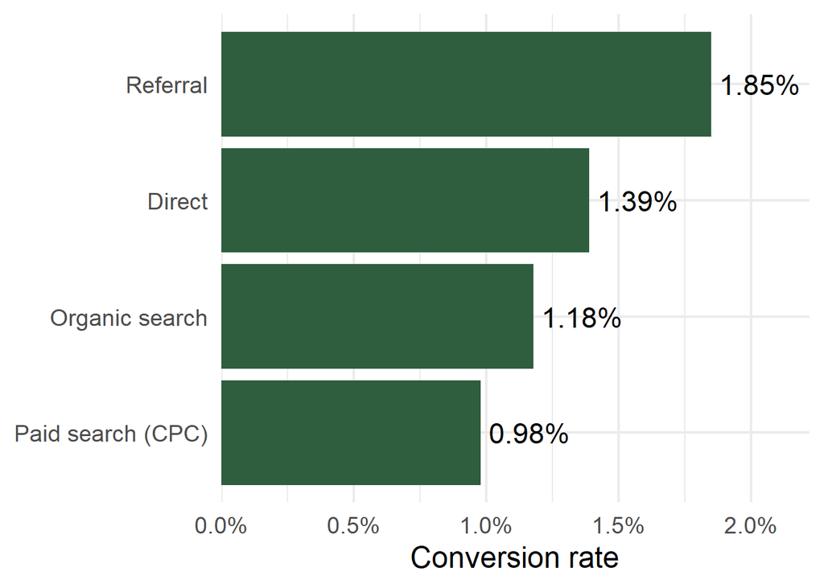

Figure 1: Visitor-to-purchase conversion rate by channel

```r
ga4 |>
  ggplot(aes(x = reorder(channel, conv_rate),
             y = conv_rate)) +
  geom_col(fill = "#2E5E3E") +
  geom_text(aes(label = percent(conv_rate, 0.01)),
            hjust = -0.1, size = 6) +
  coord_flip() +
  scale_y_continuous(labels = percent,
                     expand = expansion(mult = c(0, 0.2))) +
  labs(x = NULL,
       y = "Conversion rate") +
  theme_minimal(base_size = 18)
```

## Where Visitors Drop Off

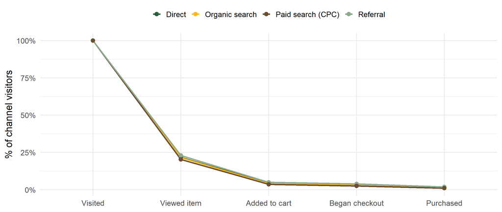

Figure 2: Share of each channel’s visitors who reach each funnel step

## Measures

Constructs and how they are operationalized

| Construct | GA4 / Google Ads metric | Scale |
| --- | --- | --- |
| Traffic acquisition | Users by medium (organic, cpc, referral, direct) | Nominal |
| Engagement | View item, add to cart, begin checkout | Ratio (counts) |
| Conversion | Purchasers / users | Ratio (%) |
| Ad efficiency | Click-through rate, cost per click | Ratio |
| Ad return | Return on ad spend (ROAS) | Ratio |
| Ad trust and perceived value | Survey items (planned) | Interval (Likert) |

## Analytics Methods

1. **Descriptive funnel analysis** by channel (Figure 2)
2. **Chi-square test of independence:** is purchasing independent of organic vs. paid channel?
3. **Pre/post comparison** once the Farm Store runs a Shopping Ads test period
4. **Survey analysis** of ad trust and perceived value as drivers of purchase intention

**Preview on sample data:** paid search converted at 0.98% vs. 1.18% for organic search, $\chi^2$ = 4.55, p = 0.033.

In Google’s store, paid traffic converted *lower* than organic search. This fits the trust and perceived value argument: ad clicks alone do not guarantee purchases (Duffett and Charles 2025). It is exactly the question the Farm Store data needs to answer before any ad budget is spent.

# Wrap Up

## Next Steps

1. Connect the Farm Store GA4 property (client approved, IT setup pending)
2. Swap the sample table name for the Farm Store GA4 export and rerun
3. Draft the ad trust and perceived value survey items
4. Recommend: paid Shopping Ads, stronger organic SEO, or both

## References

Azemi, Yllka and Wilson Ozuem (2026), “[Paid search advertising across stages of the customer shopping journey: A shopping goal theory perspective](https://doi.org/10.1108/ITP-03-2023-0223),” *Information Technology & People*, 39 (8), 32–49.

Duffett, Rodney Graeme and Jaydi Rejuan Charles (2025), “[Assessing antecedents of Google shopping ads intention to purchase: a multigroup analysis of generation Y and Z](https://doi.org/10.1108/YC-12-2023-1923),” *Young consumers*, 26 (7), 121.

Ghose, Anindya and Sha Yang (2009), “[An Empirical Analysis of Search Engine Advertising: Sponsored Search in Electronic Markets](https://doi.org/10.1287/mnsc.1090.1054),” *Management science*, 55 (10), 16051622.

Mohaimin, Md Rashed (2025), “[The influence of google analytics on e-commerce: Enhancing customer insights and business performance](https://doi.org/10.32996/jbms.2025.7.2.8),” *Journal of Business and Management Studies*, 7 (2), 91–103.

Olbrich, Rainer and Carsten D. Schultz (2014), “[Multichannel advertising: Does print advertising affect search engine advertising?](https://doi.org/10.1108/EJM-10-2012-0569)” *European Journal of Marketing*, 48 (9/10), 1731–56.

# Appendix

## A. Full BigQuery SQL

```
SELECT
  traffic_source.medium AS medium,
  COUNT(DISTINCT user_pseudo_id) AS users,
  COUNT(DISTINCT IF(event_name = 'view_item',      user_pseudo_id, NULL)) AS viewed_item,
  COUNT(DISTINCT IF(event_name = 'add_to_cart',    user_pseudo_id, NULL)) AS added_to_cart,
  COUNT(DISTINCT IF(event_name = 'begin_checkout', user_pseudo_id, NULL)) AS began_checkout,
  COUNT(DISTINCT IF(event_name = 'purchase',       user_pseudo_id, NULL)) AS purchased
FROM `bigquery-public-data.ga4_obfuscated_sample_ecommerce.events_*`
WHERE _TABLE_SUFFIX BETWEEN '20201101' AND '20210131'
GROUP BY medium
ORDER BY users DESC
```

Back to Data Wrangling

## B. Project Files

- [Live presentation (GitHub Pages)](https://jukedz.github.io/ibm6500-assignments/M06-1-Revealjs-Presentation/farm-store-ao4-presentation.html)
- [Source code and data (GitHub repo folder)](https://github.com/jukedz/ibm6500-assignments/tree/main/M06-1-Revealjs-Presentation)
- [Quarto source file (.qmd)](https://github.com/jukedz/ibm6500-assignments/blob/main/M06-1-Revealjs-Presentation/farm-store-ao4-presentation.qmd)
- [Cached GA4 query result (.csv)](https://github.com/jukedz/ibm6500-assignments/blob/main/M06-1-Revealjs-Presentation/data/ga4_channel_funnel.csv)
- [Custom theme (.scss)](https://github.com/jukedz/ibm6500-assignments/blob/main/M06-1-Revealjs-Presentation/farmstore.scss)

## C. Useful Links

- [Google’s GA4 sample e-commerce dataset documentation](https://developers.google.com/analytics/bigquery/web-ecommerce-demo-dataset)
- [GA4 BigQuery export schema](https://support.google.com/analytics/answer/7029846)
- [CPP Farm Store](https://www.cpp.edu/farmstore/)
- [Quarto Revealjs documentation](https://quarto.org/docs/presentations/revealjs/)
- [CCIDM effective Quarto slides repo](https://github.com/CCIDM/effective-quarto-slides)